# R for beginners

### ggplot2’s terminology

- DATA: must be data frames in **long** format, with each variable in a different column
- GEOMS: geometric objects, e.g. bars, lines, plots
- AESTHETICS: visual properties of geoms, e.g. position of axes, line color, point shapes, etc.
- SCALES: control how the data is converted in the elements of the plot (the mapping), e.g. greater values of a continuous y-axis appear higher up
- GUIDES: e.g. tick marks and axis labels

Many of the elements of ggplots are combined by joining them with the plus sign (+)  
If you write the ggplot command over several lines, be careful to always put + at the end of the line!

### Scatter plots with ggplot2

Let’s create some new data for a scatterplot

```r
mydata <- data.frame(xval = 1:4, yval = c(3, 5, 6, 9), group = c("A", "B", "A", "B"))
mydata
```

```
##   xval yval group
## 1    1    3     A
## 2    2    5     B
## 3    3    6     A
## 4    4    9     B
```

Now we make a simple scatterplot with `ggplot()`,  
but before plotting it we save it as “myplot”

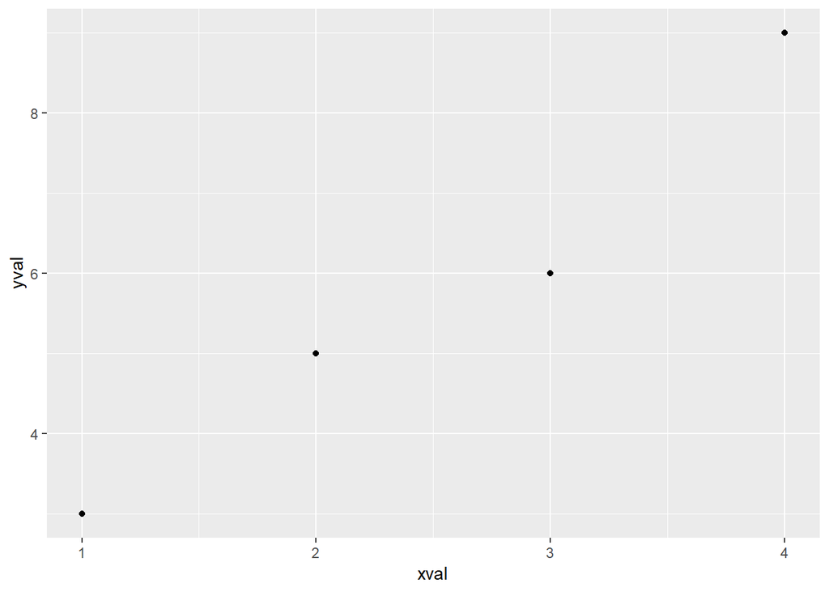

```r
myplot <- ggplot(mydata, aes(x = xval, y = yval)) + geom_point()
myplot  # then plot it by calling its name
```

You can change or add more elements to the saved plot using `+`  
For example let’s plot groups A and B in different colors:

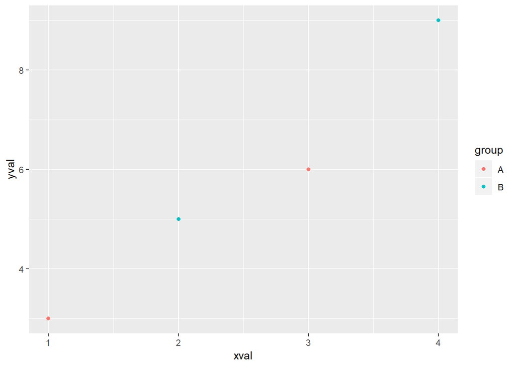

```r
myplot + geom_point(aes(colour = group))
```

Or you can change the range of the x-axis:

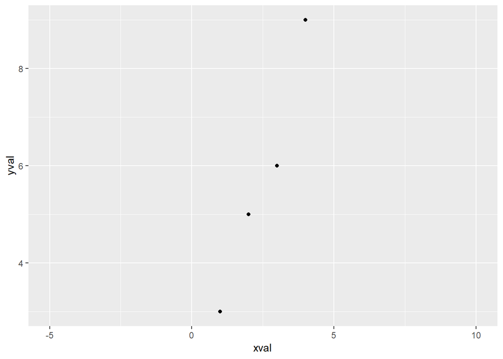

```r
myplot + scale_x_continuous(limits = c(-5, 10))
```

Change the colors:

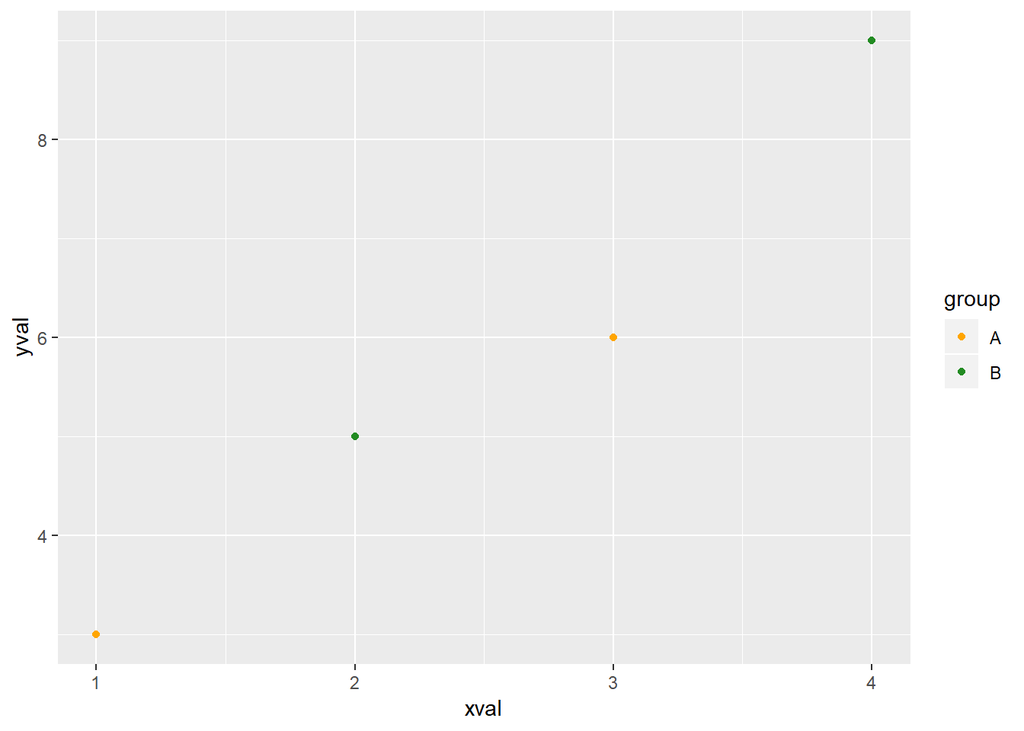

```r
myplot + geom_point(aes(colour = group)) + scale_colour_manual(values = c("orange", "forestgreen"))
```